# DƏRS 4: Rubrik Əsaslı Tələbə İnkişafının İzlənməsi

Proqressiv qiymətləndirmə və fərdi inkişaf planlaması

Azərbaycan Respublikası Təhsil Nazirliyi - Peşəkar İnkişaf Mərkəzi

2025-08-01

### 🎯 DƏRSİN ÖYRƏNMƏ MƏQSƏDLƏRİ

Bu dərsin sonunda siz aşağıdakıları bacara biləcəksiniz:

- **Proqressiv izləmə:** Tələbə inkişafını vaxt üzrə sistematik şəkildə izləmək
- **Data analizi:** Rubrik məlumatlarından anlamlı nəticələr çıxarmaq
- **Trendlərin müəyyənləşdirilməsi:** Öyrənmə nümunələrini və inkişaf istiqamətlərini tapmaq
- **Fərdi müdaxilə planları:** Hər tələbə üçün spesifik dəstək strategiyaları hazırlamaq
- **Vizual dashboard:** İnkişaf məlumatlarını effektiv şəkildə təqdim etmək
- **Prediktiv modelləmə:** Gələcək performansı proqnozlaşdırma texnikaları

# 1 Tələbə İnkişafının İzlənməsi Sisteminin Əsasları

Rubrik əsaslı izləmə sistemi tələbələrin vaxt üzrə dəyişən performansını və öyrənmə nümunələrini sistematik şəkildə qeydə alır və təhlil edir.

```r
# Tələbə məlumatlarının simulyasiyası - 30 tələbə, 8 qiymətləndirmə dövrü
set.seed(2024)

# Əsas tələbə məlumatları
students_base <- tibble(
  Student_ID = 1:30,
  Student_Name = paste("Tələbə", 1:30),
  Grade_Level = sample(c("9-cu", "10-cu", "11-ci"), 30, replace = TRUE, prob = c(0.4, 0.35, 0.25)),
  Initial_Level = sample(c("Başlanğıc", "Orta", "Yüksək"), 30, replace = TRUE, prob = c(0.3, 0.5, 0.2)),
  Learning_Style = sample(c("Vizual", "Auditiv", "Kinetetik", "Qarışıq"), 30, replace = TRUE)
)

# Vaxt üzrə performans məlumatları (8 qiymətləndirmə)
create_progress_data <- function(student_id, initial_level, n_assessments = 8) {
  # Başlanğıc ballar
  base_score <- case_when(
    initial_level == "Başlanğıc" ~ runif(1, 60, 70),
    initial_level == "Orta" ~ runif(1, 70, 80),
    initial_level == "Yüksək" ~ runif(1, 80, 90)
  )

  # İnkişaf tempi (bəzi tələbələr daha sürətli irəliləyir)
  growth_rate <- runif(1, 0.5, 2.5)
  noise_level <- runif(1, 2, 6)

  # Zaman üzrə ballar (ümumi artım trendi)
  scores <- numeric(n_assessments)
  scores[1] <- base_score

  for(i in 2:n_assessments) {
    trend_increase <- growth_rate * (i - 1)
    random_noise <- rnorm(1, 0, noise_level)
    scores[i] <- pmax(pmin(scores[1] + trend_increase + random_noise, 100), 50)
  }

  tibble(
    Student_ID = student_id,
    Assessment = 1:n_assessments,
    Date = seq(as.Date("2024-09-01"), by = "2 weeks", length.out = n_assessments),
    Score = round(scores, 1)
  )
}

# Bütün tələbələr üçün proqress məlumatları
progress_data <- map2_dfr(students_base$Student_ID, students_base$Initial_Level, create_progress_data)

# Əsas məlumatlarla birləşdirmə
full_progress_data <- progress_data %>%
  left_join(students_base, by = "Student_ID")

# Əsas statistikalar
cat("📊 TƏLƏBƏ İNKİŞAF MƏLUMATLARı:\n")
```

```
#> 📊 TƏLƏBƏ İNKİŞAF MƏLUMATLARı:
```

```r
cat("============================\n")
cat("👥 Ümumi tələbə sayı:", n_distinct(full_progress_data$Student_ID), "\n")
```

```
#> 👥 Ümumi tələbə sayı: 30
```

```r
cat("📅 Qiymətləndirmə dövrləri:", n_distinct(full_progress_data$Assessment), "\n")
```

```
#> 📅 Qiymətləndirmə dövrləri: 8
```

```r
cat("📈 Orta başlanğıc bal:", round(mean(full_progress_data$Score[full_progress_data$Assessment == 1]), 1), "\n")
```

```
#> 📈 Orta başlanğıc bal: 73.4
```

```r
cat("🎯 Orta son bal:", round(mean(full_progress_data$Score[full_progress_data$Assessment == 8]), 1), "\n")
```

```
#> 🎯 Orta son bal: 83.8
```

```r
cat("📊 Orta inkişaf:", round(mean(full_progress_data$Score[full_progress_data$Assessment == 8]) -
                                mean(full_progress_data$Score[full_progress_data$Assessment == 1]), 1), "bal\n")
```

```
#> 📊 Orta inkişaf: 10.5 bal
```

```r
# İlk və son qiymətləndirmə müqayisəsi
initial_final_comparison <- full_progress_data %>%
  filter(Assessment %in% c(1, 8)) %>%
  select(Student_ID, Student_Name, Grade_Level, Initial_Level, Assessment, Score) %>%
  pivot_wider(names_from = Assessment, values_from = Score, names_prefix = "Assessment_") %>%
  mutate(
    Growth = round(Assessment_8 - Assessment_1, 1),
    Growth_Category = case_when(
      Growth >= 15 ~ "Yüksək İnkişaf",
      Growth >= 8 ~ "Orta İnkişaf",
      Growth >= 0 ~ "Zəif İnkişaf",
      TRUE ~ "Tənəzzül"
    )
  )

kable(initial_final_comparison %>% head(10),
      caption = "Tələbələrin İlk və Son Qiymətləndirmə Müqayisəsi",
      col.names = c("ID", "Ad", "Sinif", "Başlanğıc Səviyyə", "İlk Bal", "Son Bal", "İnkişaf", "Kateqoriya")) %>%
  kable_styling(bootstrap_options = c("striped", "hover", "condensed", "responsive")) %>%
  column_spec(1, bold = TRUE, color = "white", background = "#667eea") %>%
  column_spec(7, bold = TRUE, color = ifelse(head(initial_final_comparison$Growth, 10) >= 10, "#27ae60",
                                            ifelse(head(initial_final_comparison$Growth, 10) >= 5, "#f39c12", "#e74c3c"))) %>%
  column_spec(8, bold = TRUE)
```

Tələbələrin İlk və Son Qiymətləndirmə Müqayisəsi

| ID | Ad | Sinif | Başlanğıc Səviyyə | İlk Bal | Son Bal | İnkişaf | Kateqoriya |
| --- | --- | --- | --- | --- | --- | --- | --- |
| 1 | Tələbə 1 | 11-ci | Orta | 79.1 | 75.6 | -3.5 | Tənəzzül |
| 2 | Tələbə 2 | 9-cu | Orta | 70.8 | 86.1 | 15.3 | Yüksək İnkişaf |
| 3 | Tələbə 3 | 10-cu | Orta | 80.0 | 89.0 | 9.0 | Orta İnkişaf |
| 4 | Tələbə 4 | 10-cu | Yüksək | 83.8 | 95.8 | 12.0 | Orta İnkişaf |
| 5 | Tələbə 5 | 10-cu | Başlanğıc | 60.4 | 72.9 | 12.5 | Orta İnkişaf |
| 6 | Tələbə 6 | 10-cu | Başlanğıc | 69.9 | 84.5 | 14.6 | Orta İnkişaf |
| 7 | Tələbə 7 | 10-cu | Orta | 70.4 | 79.9 | 9.5 | Orta İnkişaf |
| 8 | Tələbə 8 | 9-cu | Yüksək | 88.6 | 97.4 | 8.8 | Orta İnkişaf |
| 9 | Tələbə 9 | 11-ci | Orta | 74.1 | 69.6 | -4.5 | Tənəzzül |
| 10 | Tələbə 10 | 9-cu | Başlanğıc | 60.6 | 66.4 | 5.8 | Zəif İnkişaf |

#### 📈 İnkişaf İzləmə Metodologiyası

**Formativ Qiymətləndirmə:**

- Müntəzəm aralıqlarla (həftəlik/iki həftəlik) kiçik qiymətləndirmələr
- Rubrik əsaslı davamlı performans izləmə
- Tez əks əlaqə və düzəliş imkanları

**Summativ Təhlil:**

- Dönem və il sonunda ümumi nəticələrin qiymətləndirilməsi
- Uzunmüddətli trendlərin müəyyənləşdirilməsi
- Hərtərəfli performans hesabatlarının hazırlanması

# 2 Vaxt Üzrə İnkişaf Trendlərinin Analizi

Tələbələrin öyrənmə dinamikalarını anlamaq üçün vaxt seriyası analizi və trend müəyyənləşdirmə üsulları istifadə edilir.

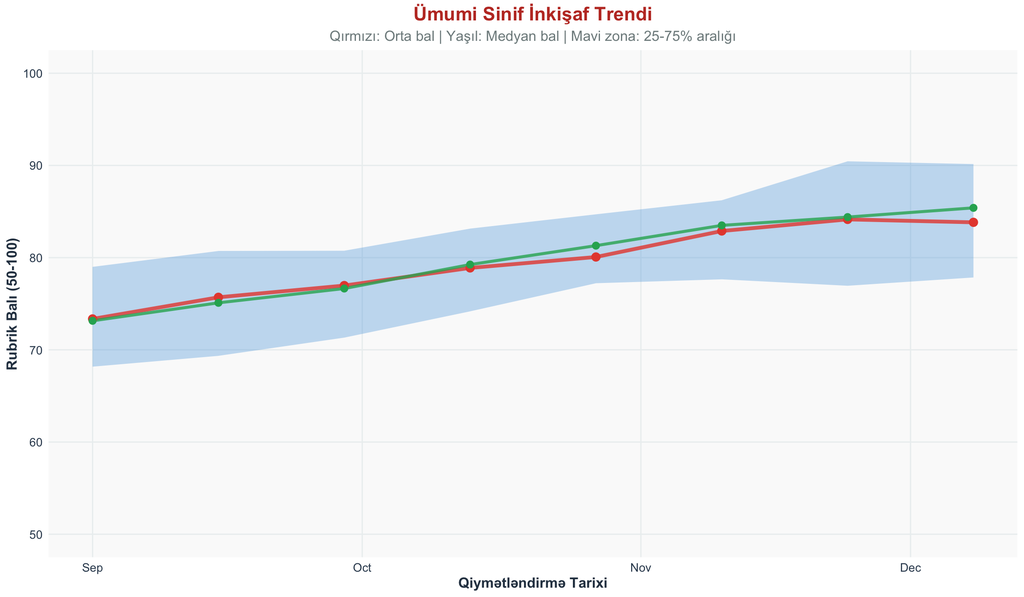

```r
# İnkişaf trendlərinin vizual təhlili
overall_progress_plot <- full_progress_data %>%
  group_by(Assessment, Date) %>%
  summarise(
    Mean_Score = mean(Score),
    Median_Score = median(Score),
    Q25 = quantile(Score, 0.25),
    Q75 = quantile(Score, 0.75),
    .groups = 'drop'
  ) %>%
  ggplot(aes(x = Date)) +
  geom_ribbon(aes(ymin = Q25, ymax = Q75), alpha = 0.3, fill = "#3498db") +
  geom_line(aes(y = Mean_Score), color = "#e74c3c", size = 1.5, alpha = 0.8) +
  geom_line(aes(y = Median_Score), color = "#27ae60", size = 1.2, alpha = 0.8) +
  geom_point(aes(y = Mean_Score), color = "#e74c3c", size = 3) +
  geom_point(aes(y = Median_Score), color = "#27ae60", size = 2.5) +
  scale_y_continuous(limits = c(50, 100), breaks = seq(50, 100, 10)) +
  labs(
    title = "Ümumi Sinif İnkişaf Trendi",
    subtitle = "Qırmızı: Orta bal | Yaşıl: Medyan bal | Mavi zona: 25-75% aralığı",
    x = "Qiymətləndirmə Tarixi",
    y = "Rubrik Balı (50-100)"
  ) +
  theme_progress_tracking()

print(overall_progress_plot)
```

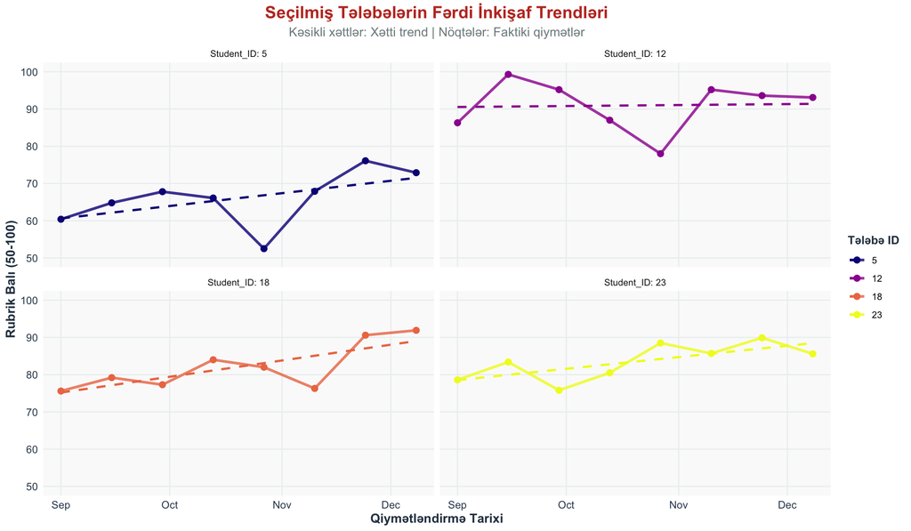

```r
# Fərdi tələbə trendləri (seçilmiş nümunələr)
selected_students <- c(5, 12, 18, 23)
individual_trends_plot <- full_progress_data %>%
  filter(Student_ID %in% selected_students) %>%
  ggplot(aes(x = Date, y = Score, color = factor(Student_ID))) +
  geom_line(size = 1.2, alpha = 0.8) +
  geom_point(size = 2.5) +
  geom_smooth(method = "lm", se = FALSE, linetype = "dashed", alpha = 0.6) +
  scale_color_viridis_d(name = "Tələbə ID", option = "plasma") +
  scale_y_continuous(limits = c(50, 100), breaks = seq(50, 100, 10)) +
  labs(
    title = "Seçilmiş Tələbələrin Fərdi İnkişaf Trendləri",
    subtitle = "Kəsikli xəttlər: Xətti trend | Nöqtələr: Faktiki qiymətlər",
    x = "Qiymətləndirmə Tarixi",
    y = "Rubrik Balı (50-100)"
  ) +
  theme_progress_tracking() +
  facet_wrap(~Student_ID, labeller = label_both)

print(individual_trends_plot)
```

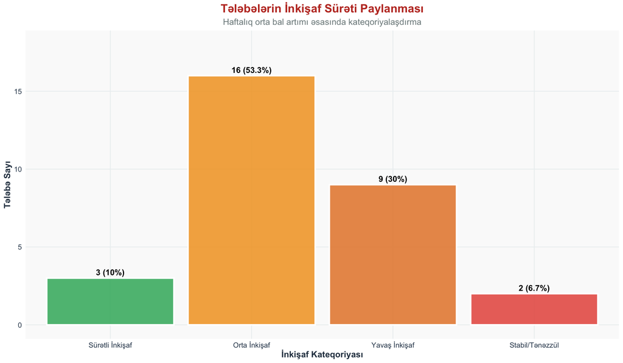

```r
# İnkişaf sürəti təhlili
growth_rate_analysis <- full_progress_data %>%
  group_by(Student_ID, Student_Name, Grade_Level, Initial_Level) %>%
  do({
    model <- lm(Score ~ Assessment, data = .)
    tibble(
      Growth_Rate = as.numeric(coef(model)[2]),
      R_Squared = summary(model)$r.squared
    )
  }) %>%
  ungroup() %>%
  mutate(
    Growth_Category = case_when(
      Growth_Rate >= 2.5 ~ "Sürətli İnkişaf",
      Growth_Rate >= 1.5 ~ "Orta İnkişaf",
      Growth_Rate >= 0.5 ~ "Yavaş İnkişaf",
      TRUE ~ "Stabil/Tənəzzül"
    ),
    Consistency = case_when(
      R_Squared >= 0.8 ~ "Yüksək",
      R_Squared >= 0.6 ~ "Orta",
      TRUE ~ "Aşağı"
    )
  )

# İnkişaf kateqoriyalarının paylanması
growth_distribution <- growth_rate_analysis %>%
  count(Growth_Category) %>%
  mutate(
    Percentage = round(n / sum(n) * 100, 1),
    Growth_Category = factor(Growth_Category,
                            levels = c("Sürətli İnkişaf", "Orta İnkişaf", "Yavaş İnkişaf", "Stabil/Tənəzzül"))
  )

growth_dist_plot <- growth_distribution %>%
  ggplot(aes(x = Growth_Category, y = n, fill = Growth_Category)) +
  geom_col(alpha = 0.8, color = "white", size = 1) +
  geom_text(aes(label = paste0(n, " (", Percentage, "%)")),
            vjust = -0.5, fontface = "bold", size = 4) +
  scale_fill_manual(values = c("Sürətli İnkişaf" = "#27ae60", "Orta İnkişaf" = "#f39c12",
                              "Yavaş İnkişaf" = "#e67e22", "Stabil/Tənəzzül" = "#e74c3c")) +
  scale_y_continuous(limits = c(0, max(growth_distribution$n) + 2)) +
  labs(
    title = "Tələbələrin İnkişaf Sürəti Paylanması",
    subtitle = "Haftalıq orta bal artımı əsasında kateqoriyalaşdırma",
    x = "İnkişaf Kateqoriyası",
    y = "Tələbə Sayı",
    fill = "Kateqoriya"
  ) +
  theme_progress_tracking() +
  theme(legend.position = "none")

print(growth_dist_plot)
```

```r
cat("\n📈 İNKİŞAF SÜRƏTİ TƏHLİLİ:\n")
```

```
#>
#> 📈 İNKİŞAF SÜRƏTİ TƏHLİLİ:
```

```r
cat("=========================\n")
for(i in 1:nrow(growth_distribution)) {
  category <- growth_distribution$Growth_Category[i]
  count <- growth_distribution$n[i]
  percentage <- growth_distribution$Percentage[i]
  cat(sprintf("📊 %s: %d tələbə (%.1f%%)\n", category, count, percentage))
}
```

```
#> 📊 Orta İnkişaf: 16 tələbə (53.3%)
#> 📊 Stabil/Tənəzzül: 2 tələbə (6.7%)
#> 📊 Sürətli İnkişaf: 3 tələbə (10.0%)
#> 📊 Yavaş İnkişaf: 9 tələbə (30.0%)
```

```r
cat(sprintf("\n🎯 Orta inkişaf sürəti: %.2f bal/həftə\n", mean(growth_rate_analysis$Growth_Rate)))
```

[output not shown]

```r
cat(sprintf("⭐ Ən yüksək inkişaf sürəti: %.2f bal/həftə\n", max(growth_rate_analysis$Growth_Rate)))
```

```
#> ⭐ Ən yüksək inkişaf sürəti: 2.89 bal/həftə
```

```r
cat(sprintf("⚠️ Ən aşağı inkişaf sürəti: %.2f bal/həftə\n", min(growth_rate_analysis$Growth_Rate)))
```

```
#> ⚠️ Ən aşağı inkişaf sürəti: -0.46 bal/həftə
```

#### 📊 Data Analizi Metodları

**Deskriptiv Statistika:**

- Mərkəzi meyllər (ortalama, medyan, mod) və yayılma göstəriciləri
- Performans paylanmasının analiz edilməsi
- Zaman üzrə dəyişmə və variasiya hesablamaları

**İnferensial Statistika:**

- Xətti və qeyri-xətti trend modellərinin qurulması
- Korrelyasiya və reqressiya analizi
- Fərqlərin statistik əhəmiyyətliliyinin yoxlanması

# 3 Performans Paternlərinin Aşkarlanması

Tələbə məlumatlarında gizli nümunələri və qruplaşmaları tapmaq üçün müxtəlif analiz texnikalarından istifadə edilir.

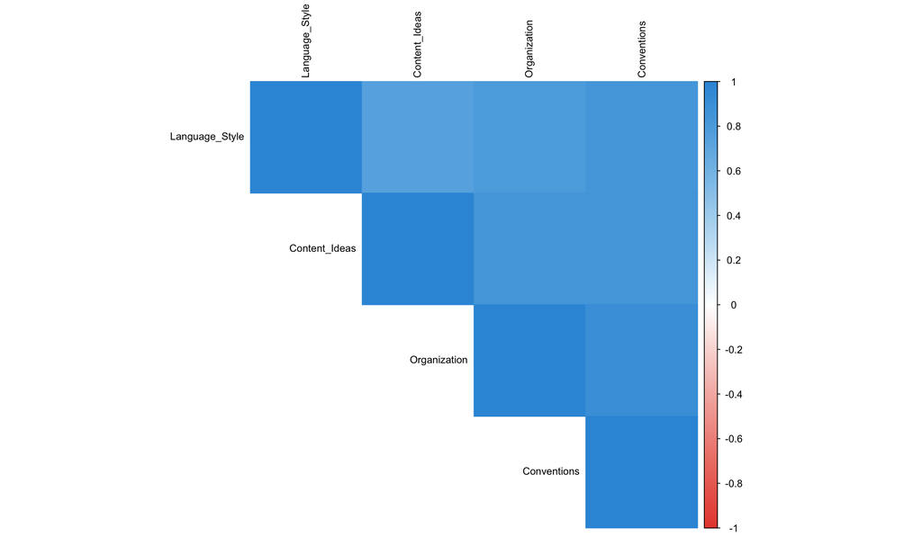

```r
# Rubrik kriteriyaları üzrə performans təhlili
# Burada biz 4 əsas kriteriyanı simulyasiya edirik
rubric_detailed_data <- full_progress_data %>%
  filter(Assessment %in% c(1, 4, 8)) %>%  # İlk, orta və son qiymətləndirmələr
  mutate(
    Content_Ideas = pmax(pmin(Score + rnorm(n(), 0, 5), 100), 50),
    Organization = pmax(pmin(Score + rnorm(n(), 0, 4), 100), 50),
    Language_Style = pmax(pmin(Score + rnorm(n(), 0, 6), 100), 50),
    Conventions = pmax(pmin(Score + rnorm(n(), 0, 3), 100), 50)
  ) %>%
  select(Student_ID, Student_Name, Assessment, Grade_Level, Initial_Level,
         Content_Ideas, Organization, Language_Style, Conventions)

# Kriteriyalar arası korrelyasiya analizi
correlation_data <- rubric_detailed_data %>%
  select(Content_Ideas, Organization, Language_Style, Conventions) %>%
  cor()

# Korrelyasiya matrisi vizualizasiyası
corrplot(correlation_data, method = "color", type = "upper",
         order = "hclust", tl.cex = 0.8, tl.col = "black",
         col = colorRampPalette(c("#e74c3c", "white", "#3498db"))(200))
```

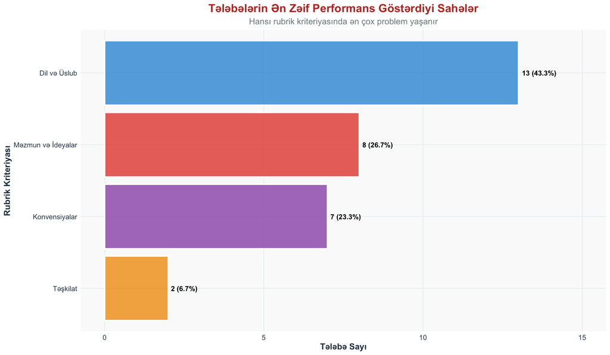

```r
# Güclü və zəif sahələrin müəyyənləşdirilməsi
strengths_weaknesses <- rubric_detailed_data %>%
  group_by(Student_ID, Student_Name) %>%
  summarise(
    across(Content_Ideas:Conventions, mean),
    .groups = 'drop'
  ) %>%
  rowwise() %>%
  mutate(
    Highest_Criteria = names(.)[which.max(c(Content_Ideas, Organization, Language_Style, Conventions)) + 2],
    Lowest_Criteria = names(.)[which.min(c(Content_Ideas, Organization, Language_Style, Conventions)) + 2],
    Strength_Score = max(c(Content_Ideas, Organization, Language_Style, Conventions)),
    Weakness_Score = min(c(Content_Ideas, Organization, Language_Style, Conventions)),
    Performance_Gap = Strength_Score - Weakness_Score
  ) %>%
  ungroup()

# Ən çox problemli sahələrin müəyyənləşdirilməsi
weakness_analysis <- strengths_weaknesses %>%
  count(Lowest_Criteria, name = "Frequency") %>%
  mutate(
    Percentage = round(Frequency / sum(Frequency) * 100, 1),
    Lowest_Criteria = case_when(
      Lowest_Criteria == "Content_Ideas" ~ "Məzmun və İdeyalar",
      Lowest_Criteria == "Organization" ~ "Təşkilat",
      Lowest_Criteria == "Language_Style" ~ "Dil və Üslub",
      Lowest_Criteria == "Conventions" ~ "Konvensiyalar"
    )
  ) %>%
  arrange(desc(Frequency))

weakness_plot <- weakness_analysis %>%
  ggplot(aes(x = reorder(Lowest_Criteria, Frequency), y = Frequency, fill = Lowest_Criteria)) +
  geom_col(alpha = 0.8, color = "white", size = 1) +
  geom_text(aes(label = paste0(Frequency, " (", Percentage, "%)")),
            hjust = -0.1, fontface = "bold", size = 3.5) +
  scale_fill_manual(values = c("Məzmun və İdeyalar" = "#e74c3c", "Təşkilat" = "#f39c12",
                              "Dil və Üslub" = "#3498db", "Konvensiyalar" = "#9b59b6")) +
  scale_y_continuous(limits = c(0, max(weakness_analysis$Frequency) + 2)) +
  coord_flip() +
  labs(
    title = "Tələbələrin Ən Zəif Performans Göstərdiyi Sahələr",
    subtitle = "Hansı rubrik kriteriyasında ən çox problem yaşanır",
    x = "Rubrik Kriteriyası",
    y = "Tələbə Sayı",
    fill = "Kriteriya"
  ) +
  theme_progress_tracking() +
  theme(legend.position = "none")

print(weakness_plot)
```

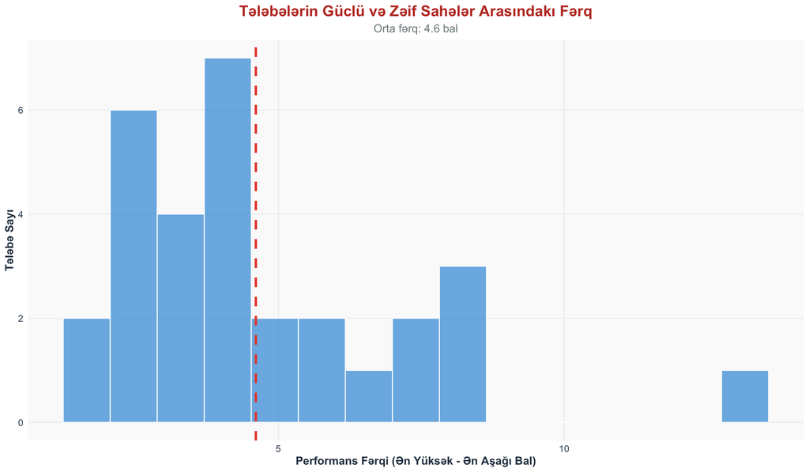

```r
# Performans fərqinin təhlili
gap_analysis_plot <- strengths_weaknesses %>%
  ggplot(aes(x = Performance_Gap)) +
  geom_histogram(bins = 15, fill = "#3498db", alpha = 0.7, color = "white") +
  geom_vline(aes(xintercept = mean(Performance_Gap)),
             color = "#e74c3c", linetype = "dashed", size = 1.2) +
  labs(
    title = "Tələbələrin Güclü və Zəif Sahələr Arasındakı Fərq",
    subtitle = paste("Orta fərq:", round(mean(strengths_weaknesses$Performance_Gap), 1), "bal"),
    x = "Performans Fərqi (Ən Yüksək - Ən Aşağı Bal)",
    y = "Tələbə Sayı"
  ) +
  theme_progress_tracking()

print(gap_analysis_plot)
```

```r
cat("\n🔍 PERFORMANS PATTERN TƏHLİLİ:\n")
```

```
#>
#> 🔍 PERFORMANS PATTERN TƏHLİLİ:
```

```r
cat("=============================\n")
cat("📊 Ən problemli sahə:", weakness_analysis$Lowest_Criteria[1],
    "(", weakness_analysis$Percentage[1], "% tələbə)\n")
```

```
#> 📊 Ən problemli sahə: Dil və Üslub ( 43.3 % tələbə)
```

```r
cat("💪 Orta performans fərqi:", round(mean(strengths_weaknesses$Performance_Gap), 1), "bal\n")
```

```
#> 💪 Orta performans fərqi: 4.6 bal
```

```r
cat("⚠️ Ən böyük fərq:", round(max(strengths_weaknesses$Performance_Gap), 1), "bal\n")
```

```
#> ⚠️ Ən böyük fərq: 12.8 bal
```

```r
cat("✅ Ən kiçik fərq:", round(min(strengths_weaknesses$Performance_Gap), 1), "bal\n")
```

```
#> ✅ Ən kiçik fərq: 1.3 bal
```

```r
# Korrelyasiya təhlili nəticələri
cat("\n🔗 KRİTERİYALAR ARASI ƏLAQƏLƏR:\n")
```

```
#>
#> 🔗 KRİTERİYALAR ARASI ƏLAQƏLƏR:
```

```r
cat("=============================\n")
for(i in 1:(ncol(correlation_data)-1)) {
  for(j in (i+1):ncol(correlation_data)) {
    corr_value <- correlation_data[i,j]
    criteria1 <- rownames(correlation_data)[i]
    criteria2 <- colnames(correlation_data)[j]

    criteria1_az <- case_when(
      criteria1 == "Content_Ideas" ~ "Məzmun",
      criteria1 == "Organization" ~ "Təşkilat",
      criteria1 == "Language_Style" ~ "Dil",
      criteria1 == "Conventions" ~ "Konvensiya"
    )
    criteria2_az <- case_when(
      criteria2 == "Content_Ideas" ~ "Məzmun",
      criteria2 == "Organization" ~ "Təşkilat",
      criteria2 == "Language_Style" ~ "Dil",
      criteria2 == "Conventions" ~ "Konvensiya"
    )

    strength <- case_when(
      abs(corr_value) >= 0.7 ~ "Güçlü",
      abs(corr_value) >= 0.4 ~ "Orta",
      TRUE ~ "Zəif"
    )

    cat(sprintf("📈 %s - %s: %.3f (%s əlaqə)\n", criteria1_az, criteria2_az, corr_value, strength))
  }
}
```

```
#> 📈 Məzmun - Təşkilat: 0.847 (Güçlü əlaqə)
#> 📈 Məzmun - Dil: 0.746 (Güçlü əlaqə)
#> 📈 Məzmun - Konvensiya: 0.847 (Güçlü əlaqə)
#> 📈 Təşkilat - Dil: 0.797 (Güçlü əlaqə)
#> 📈 Təşkilat - Konvensiya: 0.902 (Güçlü əlaqə)
#> 📈 Dil - Konvensiya: 0.837 (Güçlü əlaqə)
```

#### 🎯 Fərdi Müdaxilə Strategiyaları

**Riskli Tələbələrin Müəyyənləşdirilməsi:**

- Davamlı aşağı performans göstərən tələbələr
- Tənəzzül trendi olan tələbələr
- Böyük performans fərqi olan tələbələr

**Hədəfli Dəstək Planları:**

- Zəif sahələr üçün spesifik məşq proqramları
- Güclü sahələrin daha da inkişafı
- Fərdi öyrənmə üslubuna uyğun yanaşımlar

# 4 Prediktiv Modelləmə və Proqnozlaşdırma

Tələbələrin gələcək performansını proqnozlaşdırmaq və vaxtında müdaxilə etmək üçün prediktiv modellər istifadə edilir.

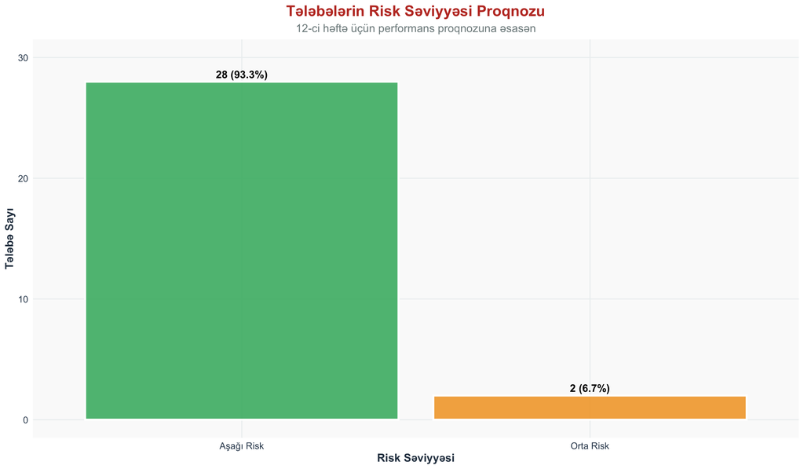

```r
# Gələcək performans proqnozlaşdırması
# Hər tələbə üçün xətti trend modeli qurulur

prediction_models <- full_progress_data %>%
  group_by(Student_ID) %>%
  do({
    model <- lm(Score ~ Assessment, data = .)
    tibble(
      Future_Score_Week10 = predict(model, newdata = data.frame(Assessment = 10)),
      Future_Score_Week12 = predict(model, newdata = data.frame(Assessment = 12)),
      Model_R_Squared = summary(model)$r.squared
    )
  }) %>%
  ungroup()

# Əsas məlumatlarla birləşdirmə
prediction_results <- prediction_models %>%
  left_join(students_base, by = "Student_ID") %>%
  left_join(
    full_progress_data %>% filter(Assessment == 8) %>% select(Student_ID, Current_Score = Score),
    by = "Student_ID"
  ) %>%
  mutate(
    Predicted_Change_10 = Future_Score_Week10 - Current_Score,
    Predicted_Change_12 = Future_Score_Week12 - Current_Score,
    Risk_Level = case_when(
      Future_Score_Week12 < 65 ~ "Yüksək Risk",
      Future_Score_Week12 < 75 ~ "Orta Risk",
      TRUE ~ "Aşağı Risk"
    ),
    Model_Reliability = case_when(
      Model_R_Squared >= 0.8 ~ "Yüksək",
      Model_R_Squared >= 0.6 ~ "Orta",
      TRUE ~ "Aşağı"
    )
  )

# Risk səviyyələrinin paylanması
risk_distribution <- prediction_results %>%
  count(Risk_Level) %>%
  mutate(
    Percentage = round(n / sum(n) * 100, 1),
    Risk_Level = factor(Risk_Level, levels = c("Aşağı Risk", "Orta Risk", "Yüksək Risk"))
  )

risk_plot <- risk_distribution %>%
  ggplot(aes(x = Risk_Level, y = n, fill = Risk_Level)) +
  geom_col(alpha = 0.8, color = "white", size = 1) +
  geom_text(aes(label = paste0(n, " (", Percentage, "%)")),
            vjust = -0.5, fontface = "bold", size = 4) +
  scale_fill_manual(values = c("Aşağı Risk" = "#27ae60", "Orta Risk" = "#f39c12", "Yüksək Risk" = "#e74c3c")) +
  scale_y_continuous(limits = c(0, max(risk_distribution$n) + 2)) +
  labs(
    title = "Tələbələrin Risk Səviyyəsi Proqnozu",
    subtitle = "12-ci həftə üçün performans proqnozuna əsasən",
    x = "Risk Səviyyəsi",
    y = "Tələbə Sayı",
    fill = "Risk"
  ) +
  theme_progress_tracking() +
  theme(legend.position = "none")

print(risk_plot)
```

```r
# Yüksək riskli tələbələr üçün detallı təhlil
high_risk_students <- prediction_results %>%
  filter(Risk_Level == "Yüksək Risk") %>%
  arrange(Future_Score_Week12) %>%
  select(Student_ID, Student_Name, Grade_Level, Initial_Level, Current_Score,
         Future_Score_Week12, Predicted_Change_12, Model_Reliability)

if(nrow(high_risk_students) > 0) {
  kable(high_risk_students,
        caption = "Yüksək Riskli Tələbələr - Fərdi Müdaxilə Tələb Edənlər",
        col.names = c("ID", "Ad", "Sinif", "Başlanğıc Səviyyə", "Hal-hazırki Bal",
                     "Proqnoz Bal", "Gözlənilən Dəyişiklik", "Model Etibarlılığı")) %>%
    kable_styling(bootstrap_options = c("striped", "hover", "condensed", "responsive")) %>%
    column_spec(1, bold = TRUE, color = "white", background = "#e74c3c") %>%
    column_spec(c(5,6,7), bold = TRUE) %>%
    row_spec(1:nrow(high_risk_students), background = "#ffe6e6")
}

# Model etibarlılığı təhlili
model_reliability_summary <- prediction_results %>%
  group_by(Model_Reliability) %>%
  summarise(
    Count = n(),
    Avg_R_Squared = round(mean(Model_R_Squared), 3),
    Avg_Current_Score = round(mean(Current_Score), 1),
    Avg_Predicted_Score = round(mean(Future_Score_Week12), 1),
    .groups = 'drop'
  )

cat("\n🔮 PREDİKTİV MODEL NƏTİCƏLƏRİ:\n")
```

```
#>
#> 🔮 PREDİKTİV MODEL NƏTİCƏLƏRİ:
```

```r
cat("==============================\n")
cat("👥 Ümumi proqnoz edilən tələbə sayı:", nrow(prediction_results), "\n")
```

```
#> 👥 Ümumi proqnoz edilən tələbə sayı: 30
```

```r
cat("⚠️ Yüksək riskli tələbələr:", sum(prediction_results$Risk_Level == "Yüksək Risk"), "\n")
```

```
#> ⚠️ Yüksək riskli tələbələr: 0
```

```r
cat("🔶 Orta riskli tələbələr:", sum(prediction_results$Risk_Level == "Orta Risk"), "\n")
```

```
#> 🔶 Orta riskli tələbələr: 2
```

```r
cat("✅ Aşağı riskli tələbələr:", sum(prediction_results$Risk_Level == "Aşağı Risk"), "\n")
```

```
#> ✅ Aşağı riskli tələbələr: 28
```

```r
cat("📊 Orta hal-hazırki bal:", round(mean(prediction_results$Current_Score), 1), "\n")
```

```
#> 📊 Orta hal-hazırki bal: 83.8
```

```r
cat("🎯 Orta proqnoz bal (12-ci həftə):", round(mean(prediction_results$Future_Score_Week12), 1), "\n")
```

```
#> 🎯 Orta proqnoz bal (12-ci həftə): 91.5
```

```r
cat("\n📈 MODEL ETİBARLILIĞI:\n")
```

```
#>
#> 📈 MODEL ETİBARLILIĞI:
```

```r
cat("===================\n")
for(i in 1:nrow(model_reliability_summary)) {
  reliability <- model_reliability_summary$Model_Reliability[i]
  count <- model_reliability_summary$Count[i]
  r_squared <- model_reliability_summary$Avg_R_Squared[i]
  cat(sprintf("🔍 %s etibarlılıq: %d tələbə (R² = %.3f)\n", reliability, count, r_squared))
}
```

```
#> 🔍 Aşağı etibarlılıq: 17 tələbə (R² = 0.386)
#> 🔍 Orta etibarlılıq: 6 tələbə (R² = 0.708)
#> 🔍 Yüksək etibarlılıq: 7 tələbə (R² = 0.886)
```